# Visualize Community-based Features

## community

```r
#TODO
```

## function naming convention

#### what’s most popular naming convention within community?

- Summary
  - Anomaly Detection is a big fan of lowerCamel, 78%, of great harmony within community. (But suffer from open curly problem most)
  - Java has its own styles => other
  - rstudio is the main advocate of lower_snake style, consistent with the overall trend across years above
  - dotted.fun gains great support from social network analysis
  - Finance, for some reason, uses UpperCamel, which is not common in other communities
  - ALLUPPER is not an abandoned naming
  - dotted.func, only proportional
- Historical reason for them?

```
##                               community      naming     ratio
## 1 Mix of Graphics and Anomaly Detection  lowerCamel 0.7774295
## 2                                  Java       other 0.5099502
## 3                       Rstudio-related lower_snack 0.4105203
## 4                      Neuronal Science    alllower 0.4046858
## 5               Social Network Analysis dotted.func 0.3314501
## 6                               Finance  UpperCamel 0.3192020
## 7          Public Health and Statistics    ALLUPPER 0.0800000
```

- main stream community
  - rstudio
- Community that is different from others
  - anomaly detection: lowerCamel
  - Finance: UpperCamel
  - Java: other
  - Public health: little snake/alllower

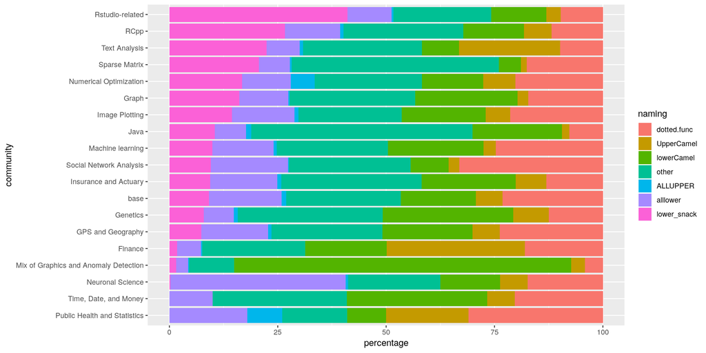

#### within each community

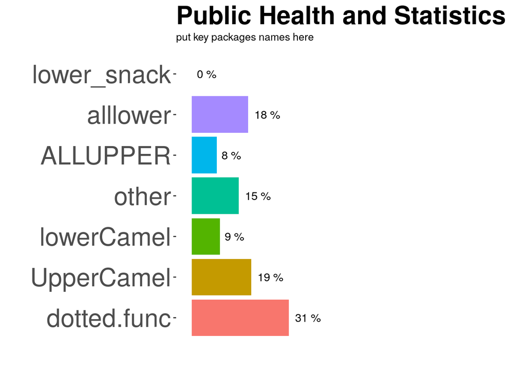

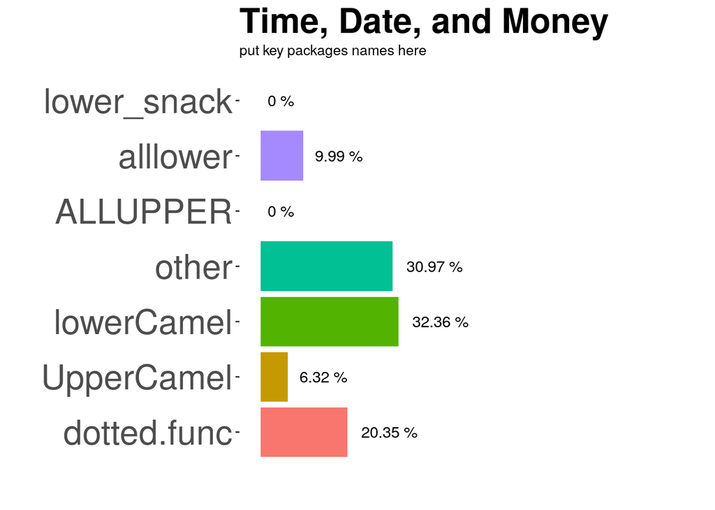

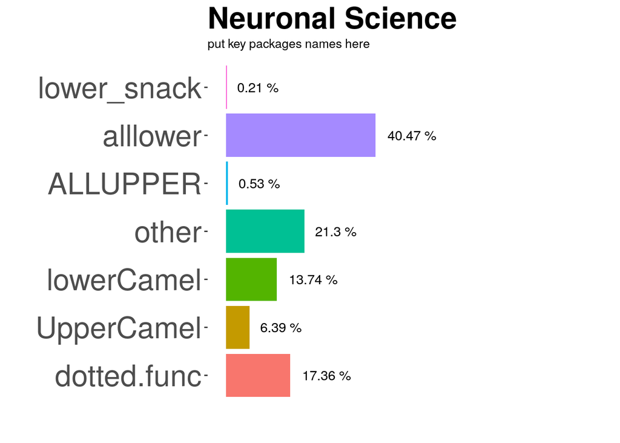

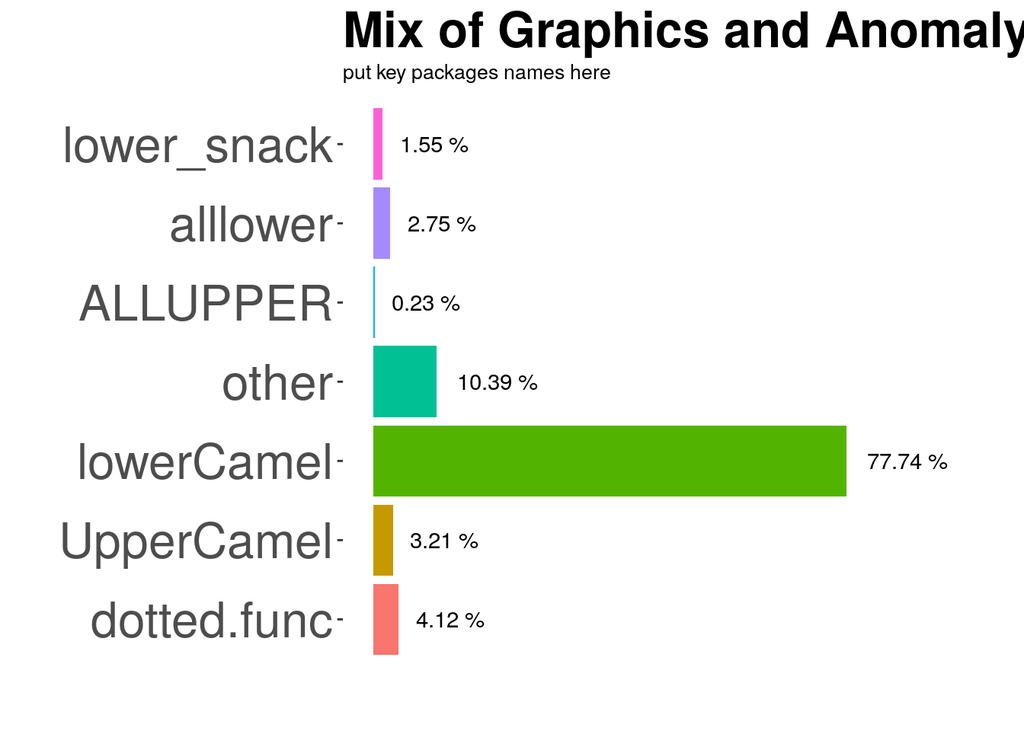

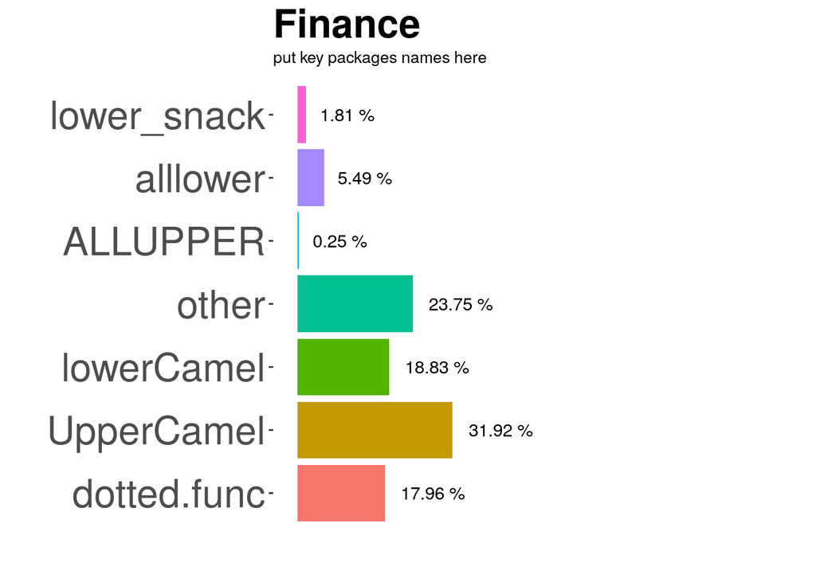

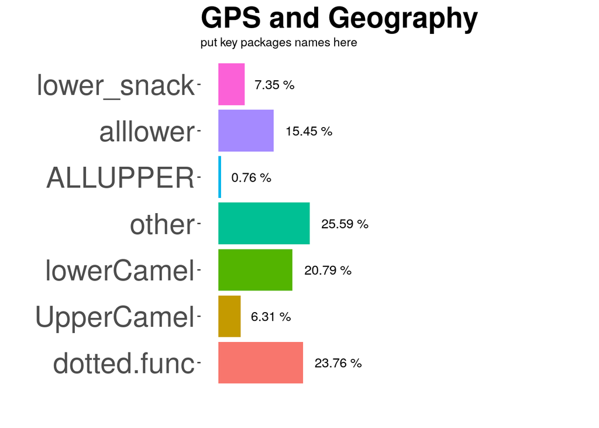

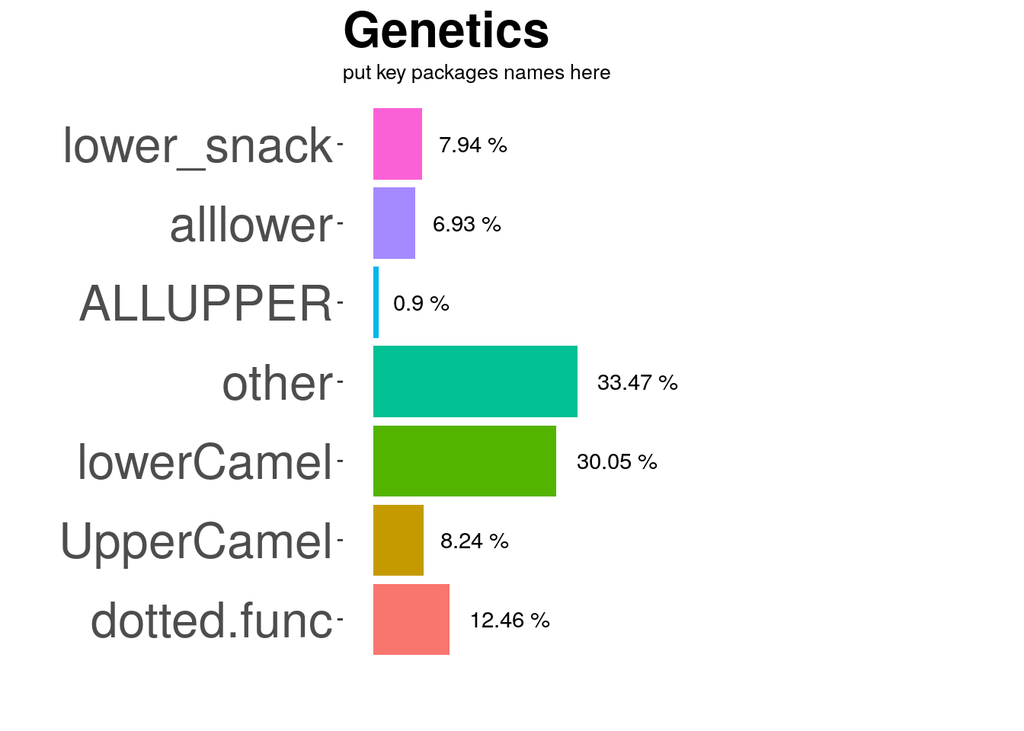

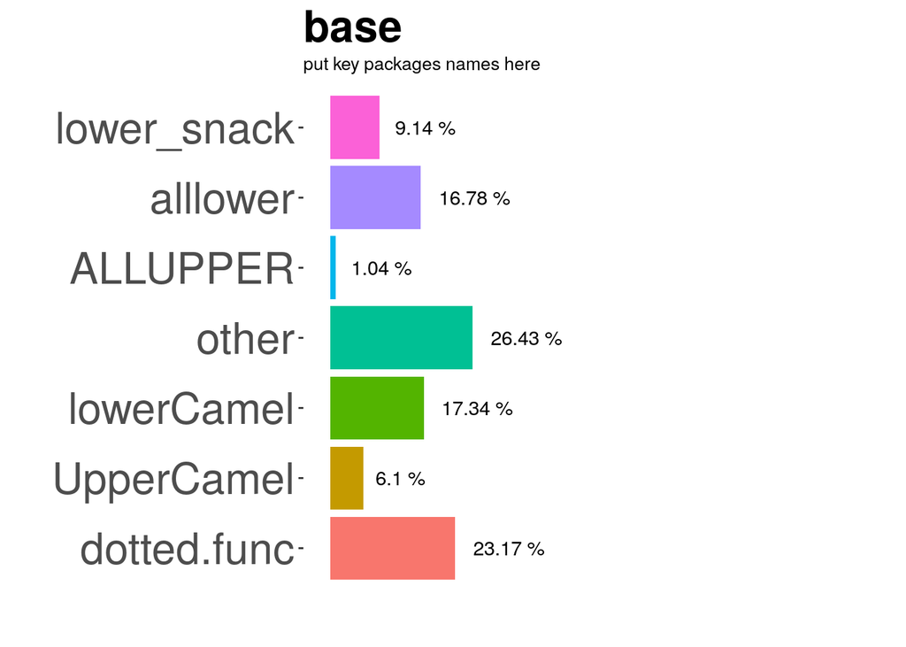

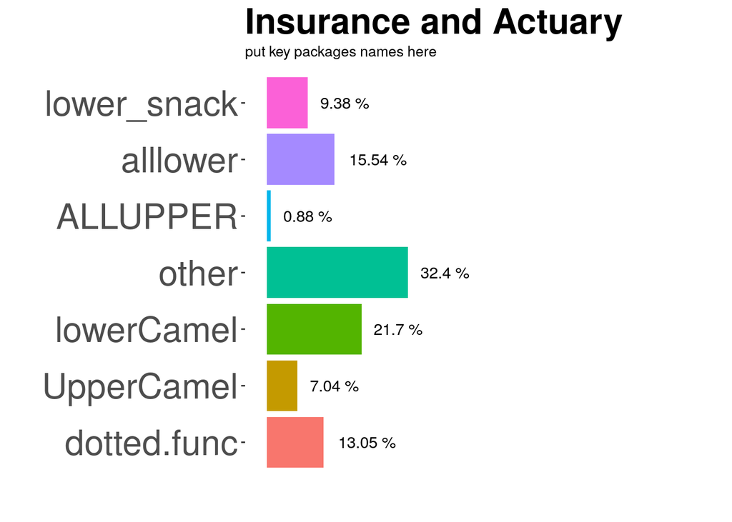

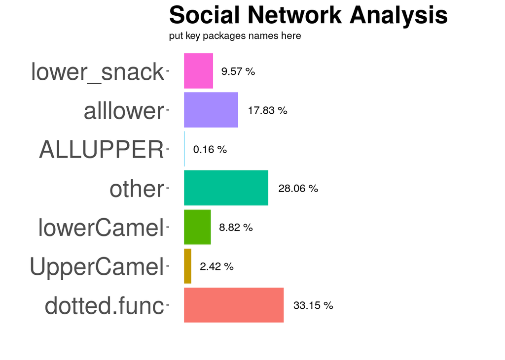

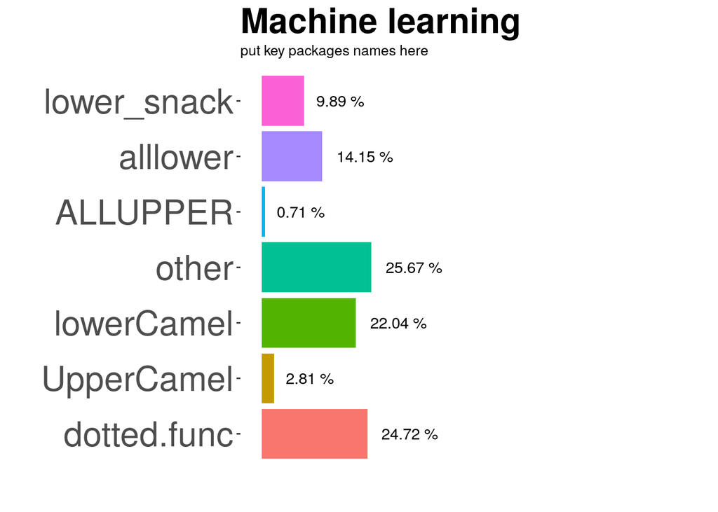

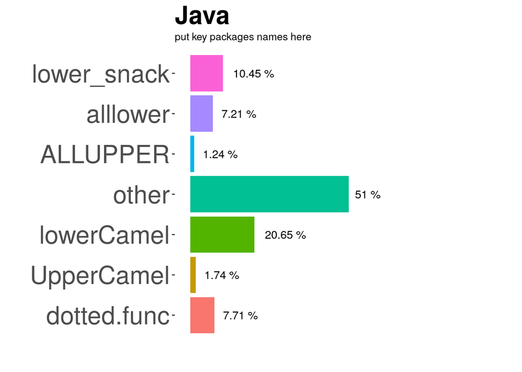

[7 more figures not shown]

```r
gen_fig_naming_dist <- function(target_community){
    df_plot <- df_naming_ratio_long %>% filter(community == target_community)
    g <- ggplot(aes(y = percentage, x = naming, fill=naming), data = df_plot) +
        geom_bar(stat="identity") + ylim(0, 100) +
        labs(title = target_community, subtitle = "put key packages names here", x = "", y = "") +
        theme_hc() + theme(legend.position = "none", panel.grid.major.y = element_blank()) +
        theme(axis.text.x = element_blank(), axis.ticks.x = element_blank()) +
        coord_flip() +
        geom_text(aes(label=sprintf("%s %s", round(percentage, 2), "%")), position = position_dodge(width=0.9), hjust = -0.25) +
        theme(plot.title = element_text(size = 24, face = "bold"), plot.subtitle =  element_text(size = 10), axis.text = element_text(size=24), text = element_text(size = 24))
    return(g)
}
#gen_fig_naming_dist(comm)

communities <- as.character(unique(df_naming_ratio_long$community))
for (comm in communities){
    g <- gen_fig_naming_dist(comm)
    print(g)
    png(sprintf("visualization_community/naming_in_comm_%s.png", comm), width = 4*96, height = 4*96)
    print(g)
    dev.off()
}
```

## cake plot: features

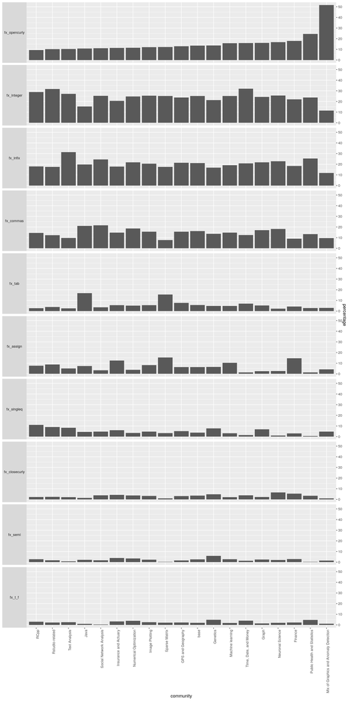